# Project B: Racial Segregation in Upstate New York

Trevor J. Kaminsky

## Overview

After initial examinations of the data, I dove deeper into the meaning behind patterns that stood out. I soon found that racial identities appeared to play a role in the geographic distribution of residents. While further research is necessary to understand why this is, it important to consider potetional reasons for this pattern to occurr.

```r
tracts <- read_csv("https://raw.githubusercontent.com/statsmaths/stat_data/gh-pages/acs_tract_data_2016.csv.gz")
unique(tracts$cbsa)
```

## Data Dictionary

Basic metadata about the tract:

state: the state in which the tract resides

county: the county in which the tract resides

cbsa: the core-based statistical area of the tract

lon: the longitude coordinates at the center of the tract

lat: the latitude coordinates at the center of the tract

population: estimated population

Race:

race_white: percentage of residents who identify as white

race_black: percentage of residents who identify as black

race_asian: percentage of residents who identify as asian

## Binghamton, NY

For my project I examined data from the U.S. Census tract in Upstate New York. In order to simplyfy matters, I focused only on census tract data concerning residents near my hometown. To do this, I filtered the original dataset by reducing the data from every resident in the United States to just those living within the core-based statistical area (cbsa) of Binghampton, NY. After the data set had been filtered, I conducted exploratory analysis with the task of searching for anamolies.

It is helpful to be familiar with the context, history, and location of the dataset when we try to gain a deeper understanding of it and its anamolies. Binghamton is a small city located in Upstate New York. Far from the famous Big Apple, the place is quite different from what people generally expect from New York. Signs of human civilization such as buildings and roadways are most apparent near the actual city itself. As you travel further from the epicenter of urban life, infrastructure rapidly vanishes as the population density declines. While there are several municipalities of moderate size along the highways that stretch out from Binghampton, most communites within the cbsa are small-towns in rural America.

```r
tracts_1 <- filter(tracts, cbsa == "Binghamton, NY")
tracts_1
```

| state | county | cbsa | lon | lat | population | hh_income_q1 | hh_income_q2 | hh_income_q3 | hh_income_q4 | hh_income_q5 | hh_income_top_5 | hh_gini | median_rent | sex_male | sex_female | age_00_17 | age_18_24 | age_25_59 | age_60_plus | race_white | race_black | race_ntvam | race_asian | race_pacif | race_other | race_multi | born_same_st | born_other_ne | born_other_midwest | … |
| --- | --- | --- | --- | --- | --- | --- | --- | --- | --- | --- | --- | --- | --- | --- | --- | --- | --- | --- | --- | --- | --- | --- | --- | --- | --- | --- | --- | --- | --- | --- |
| New York | Broome County | Binghamton, NY | -75.89006 | 42.11357 | 2133 | 6165 | 17749 | 30803 | 54303 | 107605 | 169973 | 0.4724 | 629 | 45.76 | 54.24 | 23.02 | 16.03 | 44.26 | 16.69 | 77.31 | 15.24 | 1.50 | 0.47 | 0.00 | 4.55 | 0.94 | 79.61 | 9.70 | 5.24 | … |
| New York | Broome County | Binghamton, NY | -75.97788 | 42.14917 | 1679 | 12044 | 30845 | 53336 | 85876 | 134276 | 163864 | 0.3976 | 1385 | 38.83 | 61.17 | 10.42 | 4.82 | 26.56 | 58.19 | 97.20 | 0.00 | 0.00 | 2.14 | 0.36 | 0.00 | 0.30 | 77.91 | 13.16 | 4.83 | … |
| New York | Broome County | Binghamton, NY | -75.95914 | 42.10310 | 3184 | 12097 | 28728 | 47024 | 67406 | 123878 | 213180 | 0.4061 | 729 | 46.86 | 53.14 | 21.14 | 9.39 | 44.47 | 25.00 | 84.20 | 7.91 | 0.00 | 3.49 | 0.00 | 1.88 | 2.51 | 86.68 | 4.68 | 2.42 | … |
| New York | Tioga County | Binghamton, NY | -76.26297 | 42.10471 | 3787 | 11003 | 24700 | 50047 | 76806 | 146323 | 209442 | 0.4432 | 659 | 50.65 | 49.35 | 19.91 | 11.57 | 46.50 | 22.02 | 94.98 | 2.38 | 0.00 | 0.61 | 0.00 | 0.00 | 2.03 | 62.64 | 20.54 | 3.48 | … |
| New York | Broome County | Binghamton, NY | -75.89875 | 42.11812 | 2003 | 6678 | 16743 | 28705 | 47320 | 87228 | 136031 | 0.4402 | 548 | 48.38 | 51.62 | 22.67 | 10.53 | 45.33 | 21.47 | 73.89 | 17.12 | 0.05 | 3.89 | 0.00 | 2.45 | 2.60 | 82.71 | 6.06 | 1.86 | … |
| New York | Broome County | Binghamton, NY | -75.90358 | 42.10835 | 1910 | 4015 | 12316 | 20437 | 37784 | 80779 | 126880 | 0.4942 | 662 | 44.92 | 55.08 | 25.92 | 14.19 | 45.50 | 14.40 | 81.10 | 7.38 | 0.00 | 4.19 | 0.00 | 2.41 | 4.92 | 84.35 | 10.48 | 0.54 | … |
| New York | Broome County | Binghamton, NY | -75.91043 | 42.10077 | 798 | 3337 | 11625 | 16337 | 22469 | 64301 | 99302 | 0.4828 | 518 | 54.39 | 45.61 | 6.27 | 9.77 | 55.39 | 28.57 | 76.69 | 15.41 | 1.00 | 2.13 | 0.00 | 3.13 | 1.63 | 85.92 | 9.91 | 1.15 | … |
| New York | Broome County | Binghamton, NY | -75.86218 | 42.15401 | 2682 | 18022 | 33066 | 53606 | 84597 | 191836 | 372004 | 0.4601 | 664 | 48.10 | 51.90 | 24.20 | 8.72 | 42.77 | 24.31 | 97.09 | 0.71 | 0.00 | 0.00 | 0.00 | 0.00 | 2.20 | 85.91 | 9.34 | 1.85 | … |
| New York | Broome County | Binghamton, NY | -75.99993 | 42.12351 | 4460 | 23763 | 43865 | 67504 | 110425 | 211156 | 339602 | 0.4157 | 877 | 50.22 | 49.78 | 21.26 | 8.50 | 39.37 | 30.87 | 88.92 | 1.14 | 0.00 | 5.85 | 0.36 | 1.50 | 2.22 | 75.55 | 17.98 | 3.58 | … |
| New York | Broome County | Binghamton, NY | -75.95340 | 42.12194 | 3138 | 11773 | 25850 | 37222 | 60764 | 119392 | 163220 | 0.4151 | 655 | 40.82 | 59.18 | 21.00 | 8.95 | 46.81 | 23.23 | 85.60 | 3.98 | 0.00 | 5.83 | 0.54 | 0.00 | 4.05 | 87.05 | 7.60 | 1.83 | … |

[output cut: 54 more lines]

## Graphs

In order to detect anamolies in the dataset, creating visual representations of the data can help staticians find areas of particular interest. As I looked for these hidden oddities, data concerning racial demographics caught my eye. The data revealed that racial identity of residents correlated with the geographical location of aforementioned residents.

### Distribution of White Residents

While the total popultion of many towns listed are quite small, the percentage of residents in these areas that identify as White is quite significant. Even in communities located near highways that bring attract larger populations, the racial demographics echo a similar pattern. Now although most placed depicted on the map are very homogenous, the ratio changes quite noticably near Binghamton itself with there being only a slight majority of whites.

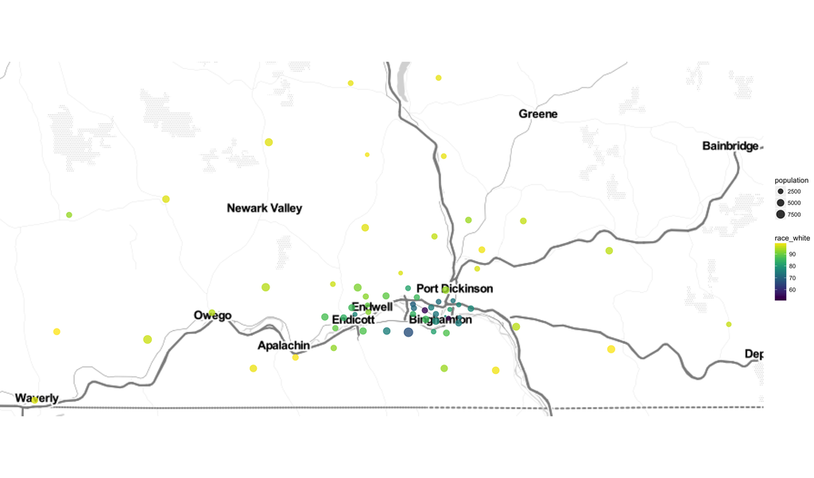

```r
qmplot(lon, lat, data = tracts_a, geom = "blank") +
  geom_point(aes(color = race_white, size = population), alpha = 0.8) +
  scale_color_viridis()
```

### Distribution of Black Residents

Although still not a majority, a significant number of resident who identify as Black live within the city limits of Binghamton. However, as shown by the map we see that there few if any residents of this minority living in the smaller communities.

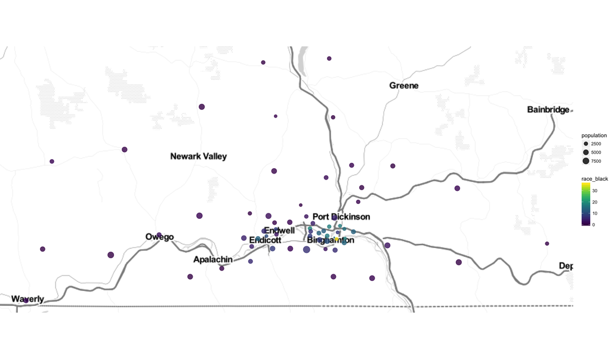

```r
qmplot(lon, lat, data = tracts_a, geom = "blank") +
  geom_point(aes(color = race_black, size = population), alpha = 0.8) +
  scale_color_viridis()
```

### Distribution of Asian Residents

Even when we exam residents who identify as Asian, another community of color, we see a similar effect. Not only do we see geographic segration of People of Color (POC) from Whites, but within the city of Binghamton itself we see an uneven distribution of different racial minorities.

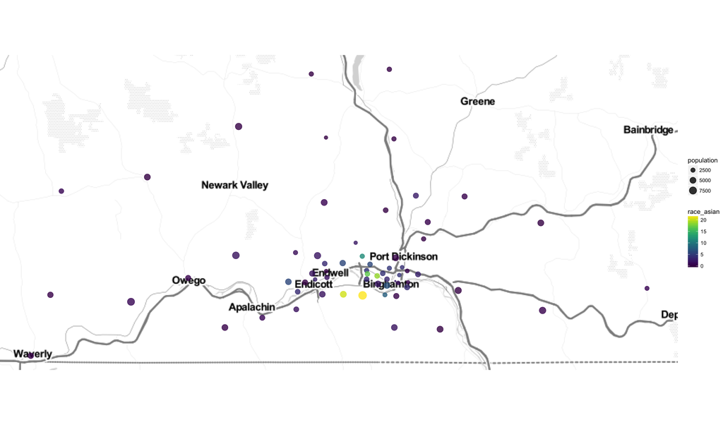

```r
qmplot(lon, lat, data = tracts_a, geom = "blank") +
  geom_point(aes(color = race_asian, size = population), alpha = 0.8) +
  scale_color_viridis()
```

## Conclusion

While Upstate New York has quite a different history than the Jim Crow South, racial segregation still occurrs. There are several possbile factors that play on role in this such as job opportunities, racial prejudice, and family connections. It is important to keep in mind that this project only utilizes exploratory data analysis and further research should be conducted before making more complex inferences.